# Schedule of Readings and Assignments

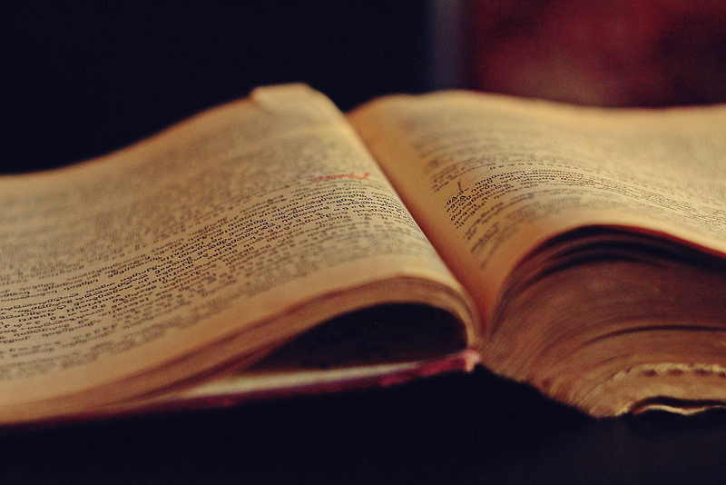

*[“Reading Book Study Student,” by ThoroughlyReviewed](https://thoroughlyreviewed.com)*

*Note: this will be an unusually busy travel semester for me. I’ve tried to indicate on the schedule when I will be traveling. Not all of these trips will affect class itself. I’ve tried to minimize cancellations and develop alternative activities for those days I cannot avoid missing. However, traveling might affect my responsiveness to email and so forth. I will strive to answer emails in a timely fashion, but if you do write while I am away from town please allow an extra half day or so before worrying about a lack of response.*

Most of the texts we will use in this class are freely available online, or in [the course packet](https://github.com/rccordell/f17rwda/blob/master/data/rwda-coursepacket.zip) (I will give you the password for this zip file in class). See the [the policies page](http://f17rwda.ryancordell.org/policies.html) for the few texts that must be purchased.

## Wednesday, September 6: Introductions

Introduction to the class and to each other

# Keyword 1: Reading

## Thursday, September 7: Novelties

Read:

- Leah Price, [“You Are What You Read”](http://www.nytimes.com/2007/12/23/books/review/Price-t.html?pagewanted=all&_r=0)
- 19th-Century Commentaries on Novel Reading:
  1. [“On Novel Reading”](http://www.merrycoz.org/books/NOVELS01.xhtml), *The Guardian; or Youth’s Religious Instructor* (1820)
  2. [“The Reading of Young Ladies”](http://www.merrycoz.org/books/LADIES.xhtml), *American Magazine of Useful Knowledge* (1836)
  3. [“Devouring Books”](http://www.merrycoz.org/books/DEVOURNG.xhtml), *The American Annals of Education* (1835)

## Monday, September 11: Paper or Plastic?

Read:

- Ferris Jabr, [“The Reading Brain in the Digital Age: The Science of Paper versus Screens”](https://www.scientificamerican.com/article/reading-paper-screens/)
- Maria Sachiko Cecire, [“Massively Open”](http://joshua-foust.squarespace.com/stories/2016/6/24/massively-open)

## Wednesday, September 13: Past Futures

Read:

- Octave Uzanne, [“The End of Books”](https://ebooks.adelaide.edu.au/u/uzanne/octave/end/) (1894)

### Prof. Cordell traveling September 14-16; regular classes

## Thursday, September 14: Reading Machines

- Craig Mod, [“Future Reading”](https://aeon.co/essays/stagnant-and-dull-can-digital-books-ever-replace-print)
- Paul La Farge, [“The Deep Space of Digital Reading”](http://nautil.us/issue/32/space/the-deep-space-of-digital-reading)

## Friday, September 15: First Blog Post on Your Domains DUE!

## Monday, September 18: 17776

Read:

- Jon Bois, [“What Football Will Look Like in the Future”](https://www.sbnation.com/a/17776-football/)

## Wednesday, September 20: Essay Workshop

### Prof. Cordell traveling September 21-24; regular classes

## Thursday, September 21: The Library that is the Universe

- Jorge Louis Borges, [“The Library of Babel”](https://libraryofbabel.info/libraryofbabel.html)

## Friday, September 22: Essay DUE

# Interlude: *Ready Player One*

## Monday, September 25: RPO I

Read:

Ernest Cline, *Ready Player One*, 0000 and Level One

# Keyword 2: Writing

## Wednesday, September 27: Writing as Technology

Read:

- Ted Chiang, [“The Truth of Fact, the Truth of Feeling”](https://subterraneanpress.com/magazine/fall_2013/the_truth_of_fact_the_truth_of_feeling_by_ted_chiang)

## Thursday, September 28: Writing as Programming as Writing

Read:

- Stephen Ramsay and Geoffrey Rockwell, [“Untitled Number 4: A Brechto-Socratic Dialogue”](http://www.geoffreyrockwell.com/publications/u4.4.pdf)

## Monday, October 2: Programmatic Writing I

Watch:

- Jetson et al, [*Sunspring*](http://video.arstechnica.com/watch/sunspring-sci-fi-short-film)

Browse (choose at least 1 you’d like to discuss in class and get to know it):

- Helen J. Burgess, [“Love Notes and Intimate Circuits”](http://hyperrhiz.io/hyperrhiz13/missives-of-love/mashbot.html)
- [Electronic Literature Collection: Bots](http://collection.eliterature.org/3/collection-bots.html)
- Any of the bots mentioned in [this *New Yorker* article](http://www.newyorker.com/tech/elements/the-rise-of-twitter-bots) (there’s some overlap from above)
- Amaranth Borsuk, Jesper Juul, and Nick Montfort, [“The Deletionist”](http://thedeletionist.com/)
- Computational Poems by Nick Montfort:
- [“The Purpling”](https://nickm.com/poems/the_purpling/index.html)
- [“Shivers”](https://nickm.com/poems/shivers.html)
- [“Modern Perverbs”](https://nickm.com/poems/perverbs.html)

## Wednesday, October 4: Programmatic Writing II

Read:

- Samuel Woolley, Danah Boyd, Meredith Broussard, Made, [“How to Think About Bots”](https://motherboard.vice.com/en_us/article/qkzpdm/how-to-think-about-bots)

Browse:

- [Resistbot](https://resistbot.io/)
- @burnedyourtweet
- @[congressedits](https://twitter.com/congressedits?lang=en)
- @Every3Minutes
- @NSA_PRISMbot
- @NRA_Tally
- @FBIbot

## Thursday, October 5: Internet Famous

Read:

- Abby Rabinowitz, [“The Meme as Meme”](http://nautil.us/issue/5/fame/the-meme-as-meme)
- Jim Ridolfo and Dànielle Nicole DeVoss, [“Composing for Recomposition: Rhetorical Velocity and Delivery”](http://kairos.technorhetoric.net/13.2/topoi/ridolfo_devoss/intro.html) (make sure to read each of the sections in the table of contents at the top)

## Monday, October 9: Holiday—No Class

## Wednesday, October 11: It’s Pronounced ‘Gif’

Read:

- Kate M. Miltner and Tim Highfield, [“Never Gonna GIF You Up: Analyzing the Cultural Significance of the Animated GIF”](http://journals.sagepub.com/doi/full/10.1177/2056305117725223)
- Lauren M. Jackson, [“We Need to Talk About Digital Blackface in GIFs”](http://www.teenvogue.com/story/digital-blackface-reaction-gifs)

### Prof. Cordell traveling October 12-14; early dismissal on Oct. 12

## Thursday, October 12: Wikiworld

Read:

- Joseph Reagle, [“Nazis and Norms”](http://reagle.org/joseph/2010/gfc/chapter-1.html), [“The Pursuit of the Universal Encyclopedia”](http://reagle.org/joseph/2010/gfc/chapter-2.html), and [“Encyclopedic Anxiety”](http://reagle.org/joseph/2010/gfc/chapter-7.html)
- [Gender Bias on Wikipedia](https://en.wikipedia.org/wiki/Gender_bias_on_Wikipedia)

## Monday, October 16: Fake News

Listen:

- 99% Invisible, [“The Age of the Algorithm”](http://99percentinvisible.org/episode/the-age-of-the-algorithm/)

Read:

- Robert Darnton, [“The True History of Fake News”](http://www.nybooks.com/daily/2017/02/13/the-true-history-of-fake-news/)
- Tom Standage, [“The True History of Fake News”](https://www.1843magazine.com/technology/rewind/the-true-history-of-fake-news)

### Prof. Cordell traveling Oct. 17-21; classes led by Amanda Rust on Oct. 18 & 19

## Wednesday, October 18: Wiki assignment workshop

## Thursday, October 19: Wiki assignment workshop

# Keyword 3: Data

## Monday, October 23: That’s So Meta

Read:

- Alexis C. Madrigal, [“How Netflix Reverse Engineered Hollywood”](http://www.theatlantic.com/technology/archive/2014/01/how-netflix-reverse-engineered-hollywood/282679/)

## Wednesday, October 25: Don’t Be Evil

Read:

- Naomi Kritzer, [“Cat Pictures Please”](http://clarkesworldmagazine.com/kritzer_01_15/)

### Prof. Cordell traveling Oct. 26-29; regular classes

## Thursday, October 26: Quantified Selves

Read:

- Giorgia Lupi and Stefanie Posavec, from [*Dear Data*](http://www.dear-data.com/theproject/) (find 3 posts you find compelling and bring them with you to class prepared to talk about why)
- Gary Wolf, [“The Data-Driven Life”](http://www.nytimes.com/2010/05/02/magazine/02self-measurement-t.html?pagewanted=all&_r=0)

## Friday, October 27: Wiki assignment DUE

## Monday, October 30: Data Afterlives

Watch:

- Owen Harris, “Be Right Back” episode of *Black Mirror*

## Wednesday, November 1: Data Transcendent

Read:

- Ted Chiang, [“The Lifecycle of Software Objects”](https://subterraneanpress.com/magazine/fall_2010/fiction_the_lifecycle_of_software_objects_by_ted_chiang)

# Interlude: *Ready Player One*

## Thursday, November 2: RPO II

Read:

Ernest Cline, *Ready Player One*, Level Two

## Monday, November 6: Dear (My) Data planning workshop

### Prof. Cordell traveling Nov. 8-11; no class Nov. 9

# Keyword 4: Attention

## Wednesday, November 8: What Gorilla?

Read:

- Cathy Davidson, from *Now You See It*

## Thursday, November 9: No class

## Monday, November 13: #Unplug

Read:

- Baratunde Thurston, [“#Unplug: Baratunde Thurston Left The Internet For 25 Days, And You Should Too”](http://www.fastcompany.com/3012521/unplug/baratunde-thurston-leaves-the-internet)
- Ian Bogost, [“Hyperemployment, or the Exhausting Work of the Technology User”](http://www.theatlantic.com/technology/archive/2013/11/hyperemployment-or-the-exhausting-work-of-the-technology-user/281149/)

## Wednesday, November 15: That’s Uncanny!

Read:

- Virginia Heffernan, [“The Internet Is the Uncanniest Valley. Don’t Get Trapped in It”](https://www.wired.com/2017/08/uncanny-valley-internet/)

## Thursday, November 16: OPEN DAY

## Friday, November 17: Dear (My) Data Draft Due

# Interlude: *Ready Player One*

## Monday, November 20: RPO III

Read:

Ernest Cline, *Ready Player One*, Level Three

# Keyword 5: Play

## Monday, November 27: This Cake is Great

Play:

- Valve, *Portal*

Read:

- Michael Burden and Sean Gouglas, [“The Algorithmic Experience: Portal As Art”](http://gamestudies.org/1202/articles/the_algorithmic_experience)

## Wednesday, November 29: Arcade

Read:

- Janine Fron, Tracy Fullerton, Jacquelyn Ford Morie, and Celia Pearce, [“The Hegemony of Play”](http://homes.lmc.gatech.edu/~cpearce3/PearcePubs/HegemonyOfPlayFINAL.pdf)
- Elizabeth Losh, [“#GamerGate 101”](http://virtualpolitik.blogspot.com/2014/10/gamergate-101.html)

We’ll play (some of) these in class:

- merritt k, [*Lim*](https://a-dire-fawn.itch.io/lim)
- Molleindustria, [*Unmanned*](http://unmanned.molleindustria.org/)
- GOP Arcade, [*Thoughts and Prayers*](https://www.thoughtsandprayersthegame.com/)
- Jordan Magnuson and Kevin MacLeod, [*Loneliness*](http://www.necessarygames.com/my-games/loneliness/flash)
- Anna Anthropy, [*Queers in Love at the End of the World*](http://auntiepixelante.com/endoftheworld/)
- Porpentine, [*Howling Dogs*](http://aliendovecote.com/uploads/twine/howlingdogs/howlingdogs.html#2o)
- ——, [*With Those We Love Alive*](http://slimedaughter.com/games/twine/wtwla/)
- McKinney, [*Spent*](http://playspent.org/html/)
- Financial Times, [*The Uber Game*](https://ig.ft.com/uber-game/)
- Zoe Quinn, Patrick Lindsey, and Isaac Schankler, [*Depression Quest*](http://www.depressionquest.com/dqfinal.html)
- Star C. Foster and Daniel Ravipinto, [*Slouching toward Bedlam*](http://www.peccable.com/if/slouching-10/src/play.html)
- Jason Nelson, [*i made this. you play this. we are enemies*](http://www.secrettechnology.com/madethis/enemy6.html)

## Thursday, November 30: Choose Your Own Adventure

Choose one of the following to play. You need to get far enough into the game that you can talk about it in detail during class, so start well in advance of this session:

- [*Braid*](http://braid-game.com/)
- [*A Dark Room*](http://adarkroom.doublespeakgames.com/) (the app provides a fuller narrative)
- [*Gone Home*](http://thefullbrightcompany.com/gonehome/)
- [*Papers, Please*](http://papersplea.se/)
- [*Passage*](http://hcsoftware.sourceforge.net/passage/)
- [*Save the Date*](http://paperdino.com/save-the-date/)
- [*The Stanley Parable*](http://www.stanleyparable.com/)
- [*The Walking Dead*](http://www.telltalegames.com/walkingdead/season1/)
- [*Thomas Was Alone*](http://www.mikebithellgames.com/thomaswasalone/)
- [*To the Moon*](http://freebirdgames.com/to_the_moon/)

## Monday, December 4: Unessay workshop

## Wednesday, December 6: Wikipedia Revisions DUE

## Monday, December 11: Dear (My) Data Revisions DUE

## Thursday, December 14: Unessay Projects DUE